# Project Thera Bank by Samir Karandikar final

## 2. EDA: Study the data distribution in each attribute and target variable, share your findings (20 marks)

- Number of unique in each column?
- Number of people with zero mortgage?
- Number of people with zero credit card spending per month?
- Value counts of all categorical columns.
- Univariate and Bivariate
- Get data model ready

```python
#Finding number of unique values in each column
uniqueValues = bdata.nunique()
print('Number of unique values in each column')
print(uniqueValues)
```

```
Number of unique values in each column
ID                    5000
Age                     45
Experience              44
Income                 162
ZIP Code               467
Family                   4
CCAvg                  108
Education                3
Mortgage               347
Personal Loan            2
Securities Account       2
CD Account               2
Online                   2
CreditCard               2
dtype: int64
```

```python
#Finding number of people with zero mortgage
Zero_mort=(bdata[(bdata['Mortgage']==0) ]).count()
print('Number of People with Zero Mortgage = ', Zero_mort.iloc[0])
```

```
Number of People with Zero Mortgage =  3462
```

```python
# Number of people with zero credit card spending per month
Zero_crcard=(bdata[(bdata['CCAvg']==0) ]).count()
print('Number of people with zero credit card spending per month = ', Zero_crcard.iloc[0])
```

```
Number of people with zero credit card spending per month =  106
```

```python
print('ZIP Code Category Column top 30 value counts are shown below:\n', bdata['ZIP Code'].value_counts(normalize=True)[:30])
print('Edcation Category Column the value counts are shown below:\n', bdata['Education'].value_counts(normalize=True)[:4])
print('Personal Loan Category Column the value counts are shown below:\n', bdata['Personal Loan'].value_counts(normalize=True)[:4])
print('Securities Account Column the value counts are shown below:\n', bdata['Securities Account'].value_counts(normalize=True)[:4])
print('CD Account Category Column the value counts are shown below:\n', bdata['CD Account'].value_counts(normalize=True)[:4])
print('Online Account Column the value counts are shown below:\n', bdata['Online'].value_counts(normalize=True)[:4])
print('Credit Card Column the value counts are shown below:\n', bdata['CreditCard'].value_counts(normalize=True)[:4])
#Value counts and fraction of each value in the column is shown below
```

```
ZIP Code Category Column top 30 value counts are shown below:
 94720    0.0338
94305    0.0254
95616    0.0232
90095    0.0142
93106    0.0114
92037    0.0108
93943    0.0108
91320    0.0106
91711    0.0104
94025    0.0104
92093    0.0102
90245    0.0100
90024    0.0100
90089    0.0092
```

[output cut: 42 more lines]

```python
bdata['ZIP Code'] = bdata['ZIP Code'].astype('category')
bdata['Personal Loan'] = bdata['Personal Loan'].astype('category')
bdata['Securities Account'] = bdata['Securities Account'].astype('category')
bdata['CD Account'] = bdata['CD Account'].astype('category')
bdata['Online'] = bdata['Online'].astype('category')
bdata['CreditCard'] = bdata['CreditCard'].astype('category')
```

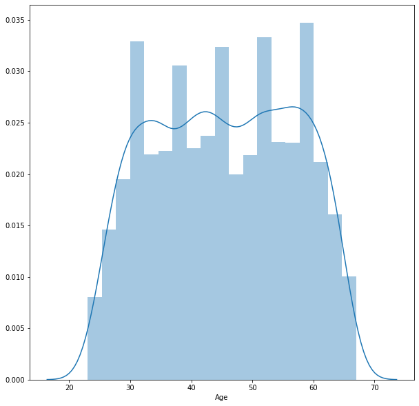

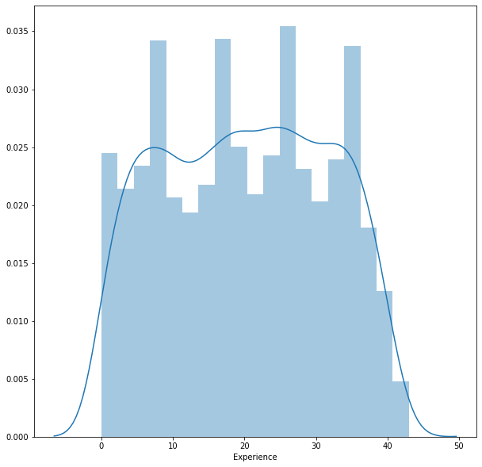

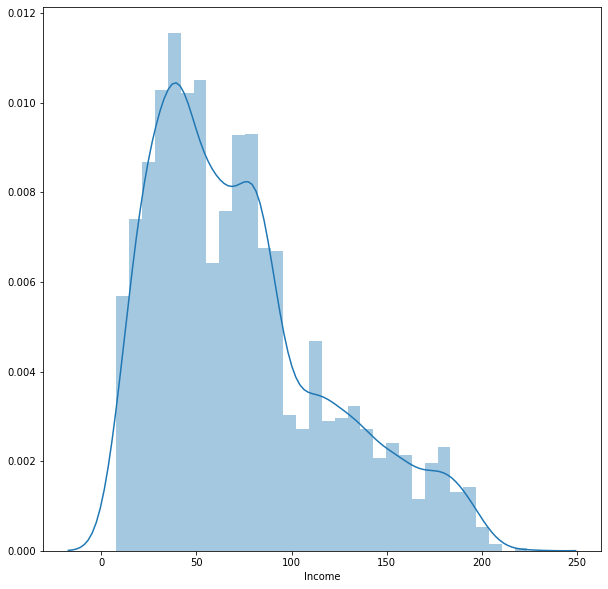

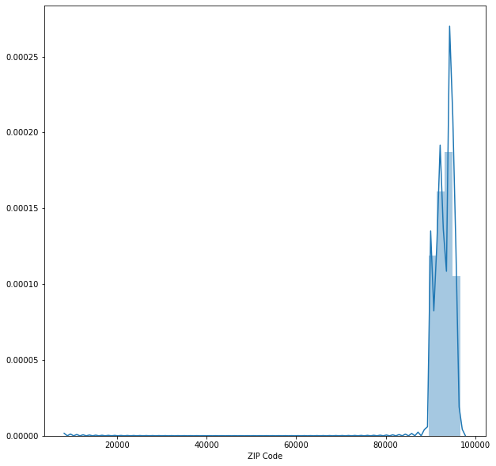

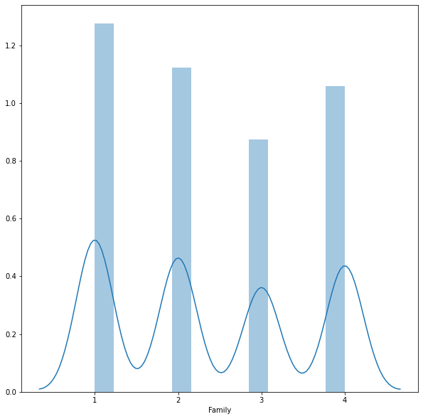

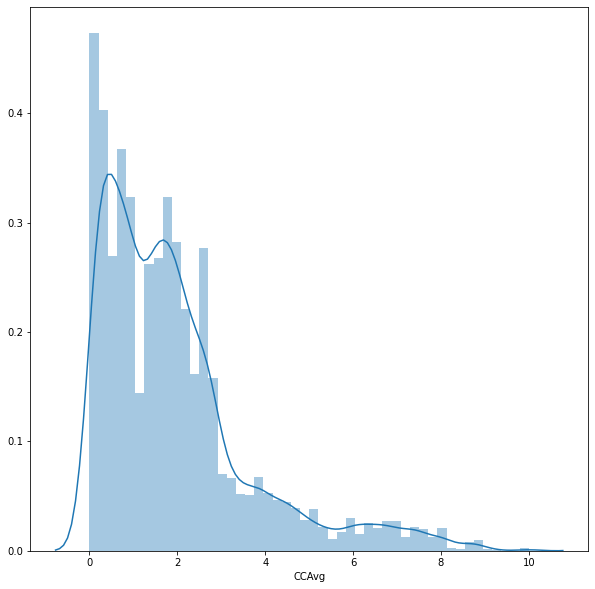

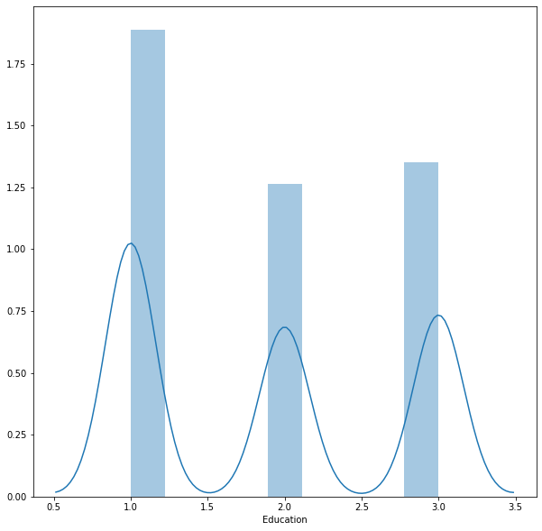

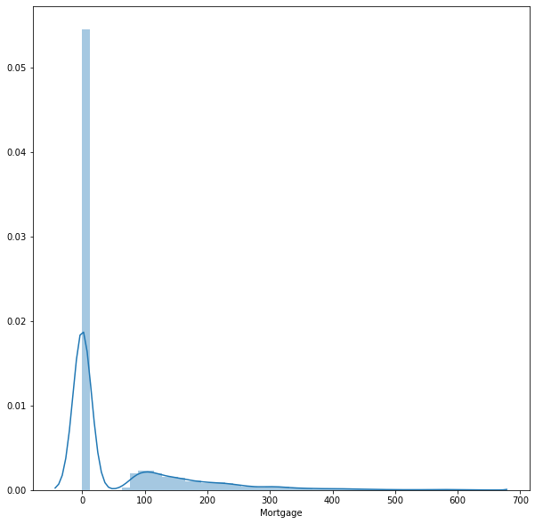

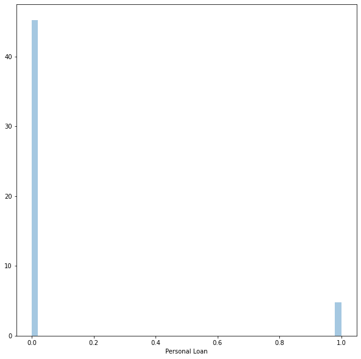

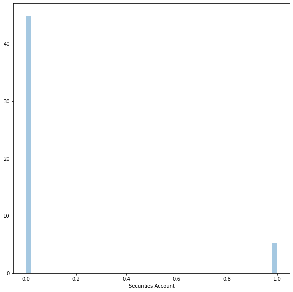

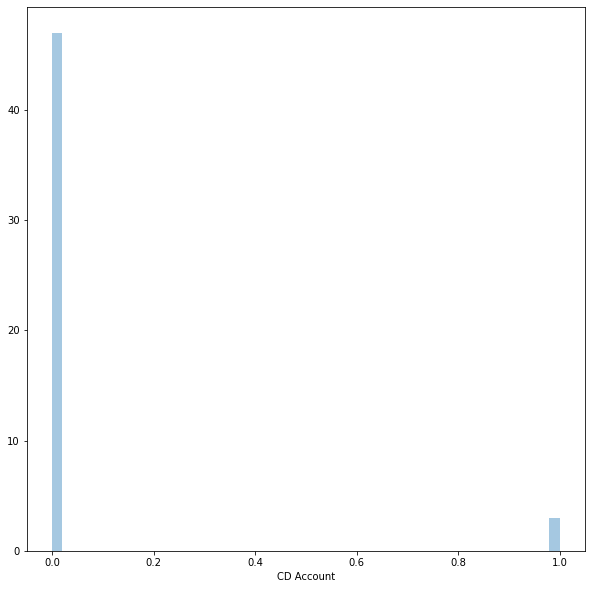

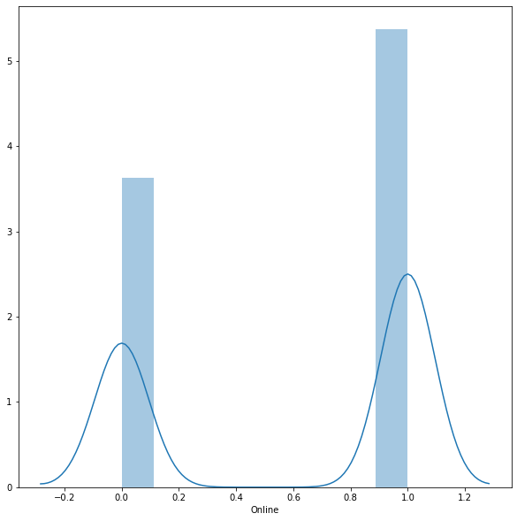

[1 more figures not shown]

```python
#Univariate Analysis for attributes and target variable
#Drop Customer ID because it will not have any meaningful value
bdata.drop(['ID'], axis=1,inplace = True)
import seaborn as sns
for i in bdata.columns:
    plt.figure(figsize = (10,10))
    sns.distplot(bdata[i])
    plt.show()
```

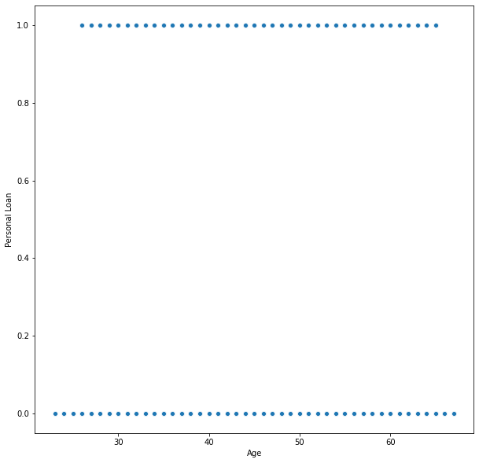

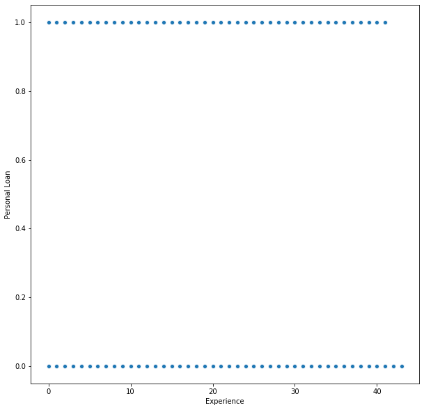

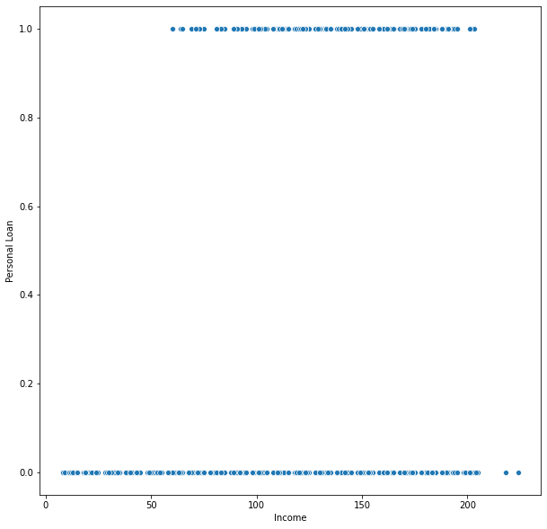

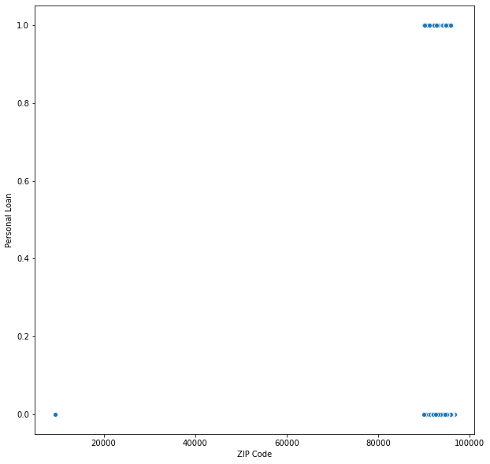

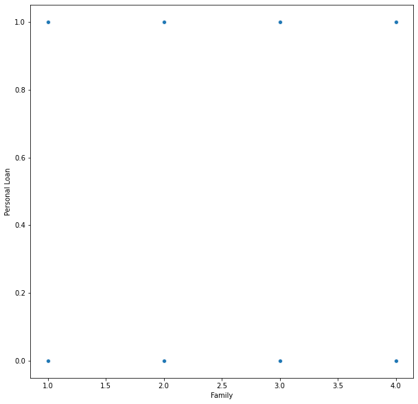

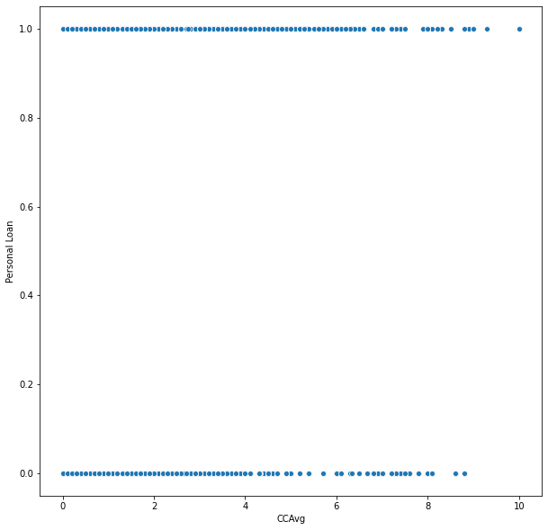

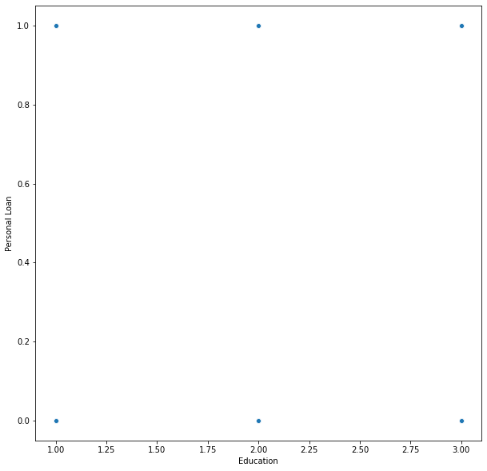

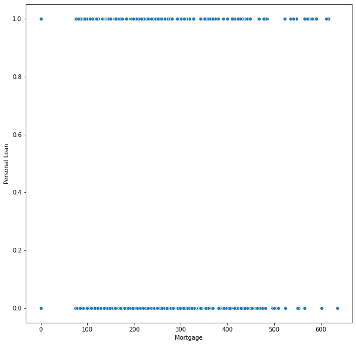

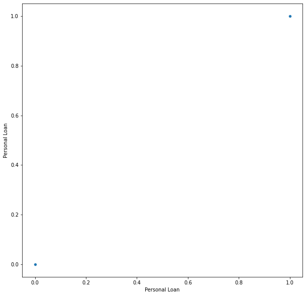

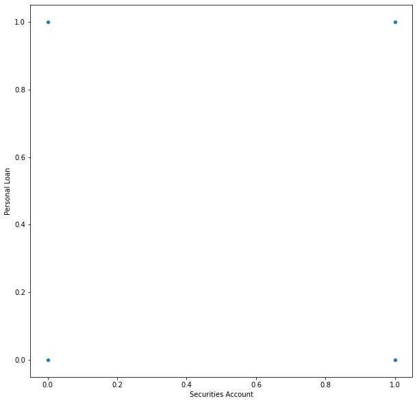

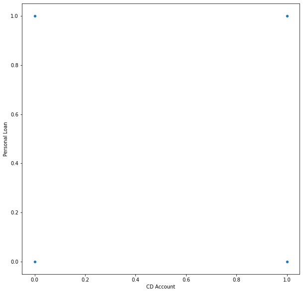

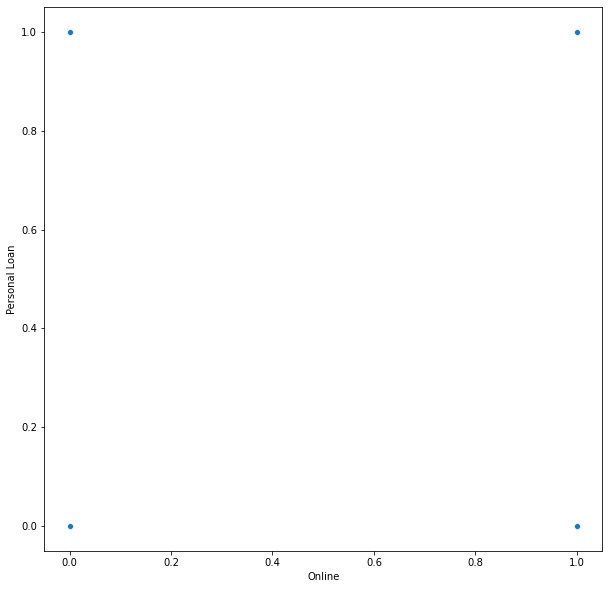

[1 more figures not shown]

```python
#Bivariate Scatterplot of Prices with all the features
#sns.pairplot(bdata,diag_kind='kde')
#Bivariate Scatterplot of Prices with all the features
for i in bdata.columns:
    plt.figure(figsize = (10,10))
    sns.scatterplot(x = bdata[i], y = bdata['Personal Loan'])
    plt.show()
```

Observations: Treatment of ZIP code has to be considered in this model.

```python
bdata.drop(['ZIP Code'], axis=1,inplace = True) # Removing Zip Code definitely helped improve the Accuracy
#In the first run I removed the features Securities Account and CD Account because more than 85% of data set do not have these
#accounts. In the subsequent runs I added these features and found that the model actually improves and finds less
# False Positive values.
#bdata.drop(['Securities Account'], axis=1,inplace = True) # Removing Securities Account because more than 85% data set has it
#bdata.drop(['CD Account'], axis=1,inplace = True) # Removing CD Account because more than 85% data set has it
```

```python
bdata2 = pd.get_dummies(bdata, prefix='Edu', columns=['Education'])
bdata2.head()
#Using One Hot Encoding for the feature Education improved the accuracy of the model from 94.6% to 95.8%
```

|  | Age | Experience | Income | Family | CCAvg | Mortgage | Personal Loan | Securities Account | CD Account | Online | CreditCard | Edu_1 | Edu_2 | Edu_3 |
| --- | --- | --- | --- | --- | --- | --- | --- | --- | --- | --- | --- | --- | --- | --- |
| 0 | 25 | 1 | 49 | 4 | 1.6 | 0 | 0 | 1 | 0 | 0 | 0 | 1 | 0 | 0 |
| 1 | 45 | 19 | 34 | 3 | 1.5 | 0 | 0 | 1 | 0 | 0 | 0 | 1 | 0 | 0 |
| 2 | 39 | 15 | 11 | 1 | 1.0 | 0 | 0 | 0 | 0 | 0 | 0 | 1 | 0 | 0 |
| 3 | 35 | 9 | 100 | 1 | 2.7 | 0 | 0 | 0 | 0 | 0 | 0 | 0 | 1 | 0 |
| 4 | 35 | 8 | 45 | 4 | 1.0 | 0 | 0 | 0 | 0 | 0 | 1 | 0 | 1 | 0 |

## 3. Split the data into training and test set in the ratio of 70:30 respectively (5 marks)

```python
from sklearn.model_selection import train_test_split

X = bdata2.drop('Personal Loan',axis=1)     # Predictor feature columns
Y = bdata2['Personal Loan']   # Predicted if Personal Loan will be taken (1=True, 0=False)

x_train, x_test, y_train, y_test = train_test_split(X, Y, test_size=0.3, random_state=1)
# 1 is just any random seed number

x_train.head()
```

|  | Age | Experience | Income | Family | CCAvg | Mortgage | Securities Account | CD Account | Online | CreditCard | Edu_1 | Edu_2 | Edu_3 |
| --- | --- | --- | --- | --- | --- | --- | --- | --- | --- | --- | --- | --- | --- |
| 1334 | 47 | 22 | 35 | 2 | 1.3 | 0 | 0 | 0 | 1 | 0 | 1 | 0 | 0 |
| 4768 | 38 | 14 | 39 | 1 | 2.0 | 0 | 0 | 0 | 1 | 0 | 0 | 1 | 0 |
| 65 | 59 | 35 | 131 | 1 | 3.8 | 0 | 0 | 0 | 1 | 1 | 1 | 0 | 0 |
| 177 | 29 | 3 | 65 | 4 | 1.8 | 244 | 0 | 0 | 0 | 0 | 0 | 1 | 0 |
| 4489 | 39 | 13 | 21 | 3 | 0.2 | 0 | 0 | 0 | 1 | 0 | 0 | 1 | 0 |

```python
print("{0:0.2f}% data is in training set".format((len(x_train)/len(bdata.index)) * 100))
print("{0:0.2f}% data is in test set".format((len(x_test)/len(bdata.index)) * 100))
```

```
70.00% data is in training set
30.00% data is in test set
```

```python
print("Original Personal Loan True Values    : {0} ({1:0.2f}%)".format(len(bdata.loc[bdata['Personal Loan'] == 1]), (len(bdata.loc[bdata['Personal Loan'] == 1])/len(bdata.index)) * 100))
print("Original Personal Loan False Values   : {0} ({1:0.2f}%)".format(len(bdata.loc[bdata['Personal Loan'] == 0]), (len(bdata.loc[bdata['Personal Loan'] == 0])/len(bdata.index)) * 100))
print("")
print("Training Personal Loan True Values    : {0} ({1:0.2f}%)".format(len(y_train[y_train[:] == 1]), (len(y_train[y_train[:] == 1])/len(y_train)) * 100))
print("Training Personal Loan False Values   : {0} ({1:0.2f}%)".format(len(y_train[y_train[:] == 0]), (len(y_train[y_train[:] == 0])/len(y_train)) * 100))
print("")
print("Test Personal Loan True Values        : {0} ({1:0.2f}%)".format(len(y_test[y_test[:] == 1]), (len(y_test[y_test[:] == 1])/len(y_test)) * 100))
print("Test Personal Loan False Values       : {0} ({1:0.2f}%)".format(len(y_test[y_test[:] == 0]), (len(y_test[y_test[:] == 0])/len(y_test)) * 100))
print("")
```

```
Original Personal Loan True Values    : 480 (9.60%)
Original Personal Loan False Values   : 4520 (90.40%)

Training Personal Loan True Values    : 331 (9.46%)
Training Personal Loan False Values   : 3169 (90.54%)

Test Personal Loan True Values        : 149 (9.93%)
Test Personal Loan False Values       : 1351 (90.07%)
```

## 4. Use the Logistic Regression model to predict whether the customer will take a personal loan or not. Print all the metrics related to evaluating the model performance (accuracy, recall, precision, f1score, and roc_auc_score). Draw a heatmap to display confusion matrix (15 marks)

```python
from sklearn import metrics

from sklearn.linear_model import LogisticRegression

# Fit the model on train
model = LogisticRegression(solver="liblinear")
model.fit(x_train, y_train)
#predict on test
y_predict = model.predict(x_test)


coef_df = pd.DataFrame(model.coef_)
coef_df['intercept'] = model.intercept_
print(coef_df)
#Coefficients and Intercept printed for information
```

```
          0         1         2         3         4        5         6  \
0 -0.296396  0.297211  0.054077  0.578668  0.195092  0.00093 -0.835325

          7         8        9        10        11       12  intercept
0  3.155815 -0.586826 -0.87551 -3.053921  0.555319  0.75445  -1.744152
```

```python
model_score = model.score(x_test, y_test)
print('Training Accuracy =', model.score(x_train, y_train))
print('Testing Accuracy =', model_score)
```

```
Training Accuracy = 0.9585714285714285
Testing Accuracy = 0.958
```

```python
## function to get confusion matrix in a proper format
def draw_cm( actual, predicted ):
    cm2 = metrics.confusion_matrix( actual, predicted)
    sns.heatmap(cm2, annot=True,  fmt='.2f', xticklabels = [0,1] , yticklabels = [0,1] )
    plt.ylabel('Observed')
    plt.xlabel('Predicted')
    plt.show()
```

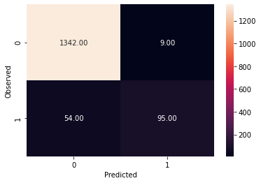

```
None
```

```python
print(draw_cm(y_test,y_predict))
```

```python
#Recall Score
from sklearn.metrics import recall_score
recall_score(y_test, y_predict, average = 'macro')
```

```
0.8154610802835582
```

```python
#Precision Score
from sklearn.metrics import precision_score
precision_score(y_test, y_predict, average = 'macro')
```

```
0.9373897950187349
```

```python
#F1 Score
from sklearn.metrics import f1_score
f1_score(y_test, y_predict, average = 'macro')
```

```
0.8640270161771879
```

```python
#ROC AUC Score
from sklearn.metrics import roc_auc_score
roc_auc_score(y_test, y_predict)
```

```
0.8154610802835582
```

```python
model.predict_proba(x_test)
```

```
array([[9.77749464e-01, 2.22505356e-02],
       [9.99862725e-01, 1.37274858e-04],
       [9.99756051e-01, 2.43949035e-04],
       ...,
       [9.97069823e-01, 2.93017670e-03],
       [9.86910632e-01, 1.30893676e-02],
       [9.99448108e-01, 5.51891673e-04]])
```

```python
# output is false-positive-rate, true-positive-rate and thresholds
from sklearn.metrics import roc_auc_score
from sklearn.metrics import roc_curve
roc_curve(y_test, model.predict_proba(x_test)[:,1])
```

[output not shown]

[output cut: 29 more lines]

[output not shown]

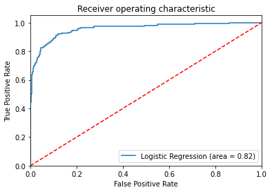

```python
logit_roc_auc = roc_auc_score(y_test, model.predict(x_test))
fpr, tpr, thresholds = roc_curve(y_test, model.predict_proba(x_test)[:,1])
plt.figure()
plt.plot(fpr, tpr, label='Logistic Regression (area = %0.2f)' % logit_roc_auc)
plt.plot([0, 1], [0, 1],'r--')
plt.xlim([0.0, 1.0])
plt.ylim([0.0, 1.05])
plt.xlabel('False Positive Rate')
plt.ylabel('True Positive Rate')
plt.title('Receiver operating characteristic')
plt.legend(loc="lower right")
plt.savefig('Log_ROC')
plt.show()
```

### Find out coefficients of all the attributes and show the output in a data frame with column names? For test data show all the rows where the predicted class is not equal to the observed class. (10 marks)

```python
## Feature Importance or Coefficients
fi = pd.DataFrame()
fi['Col'] = x_train.columns
fi['Coeff'] = np.round(abs(model.coef_[0]),2)
fi.sort_values(by='Coeff',ascending=False)
```

|  | Col | Coeff |
| --- | --- | --- |
| 7 | CD Account | 3.16 |
| 10 | Edu_1 | 3.05 |
| 9 | CreditCard | 0.88 |
| 6 | Securities Account | 0.84 |
| 12 | Edu_3 | 0.75 |
| 8 | Online | 0.59 |
| 3 | Family | 0.58 |
| 11 | Edu_2 | 0.56 |
| 0 | Age | 0.30 |
| 1 | Experience | 0.30 |
| 4 | CCAvg | 0.20 |
| 2 | Income | 0.05 |
| 5 | Mortgage | 0.00 |

```python
z = x_test.copy()
z['Observed Loan Status'] = y_test
z['Predicted Loan Status'] = y_predict
print('Rows where the Observed Loan Status does not match Predicted Loan Status')
(z[(z['Observed Loan Status']!= z['Predicted Loan Status']) ])
```

```
Rows where the Observed Loan Status does not match Predicted Loan Status
```

|  | Age | Experience | Income | Family | CCAvg | Mortgage | Securities Account | CD Account | Online | CreditCard | Edu_1 | Edu_2 | Edu_3 | Observed Loan Status | Predicted Loan Status |
| --- | --- | --- | --- | --- | --- | --- | --- | --- | --- | --- | --- | --- | --- | --- | --- |
| 932 | 51 | 27 | 112 | 3 | 1.8 | 0 | 1 | 1 | 1 | 1 | 0 | 1 | 0 | 0 | 1 |
| 4377 | 33 | 8 | 145 | 1 | 2.7 | 0 | 0 | 0 | 1 | 0 | 0 | 0 | 1 | 1 | 0 |
| 3271 | 52 | 27 | 93 | 4 | 4.1 | 0 | 0 | 0 | 0 | 1 | 0 | 1 | 0 | 1 | 0 |
| 349 | 26 | 2 | 60 | 2 | 3.0 | 132 | 0 | 0 | 0 | 0 | 1 | 0 | 0 | 1 | 0 |
| 927 | 65 | 40 | 95 | 3 | 3.7 | 138 | 0 | 0 | 0 | 1 | 0 | 1 | 0 | 1 | 0 |
| ... | ... | ... | ... | ... | ... | ... | ... | ... | ... | ... | ... | ... | ... | ... | ... |
| 464 | 43 | 19 | 83 | 4 | 3.6 | 0 | 0 | 0 | 0 | 1 | 0 | 0 | 1 | 1 | 0 |
| 1143 | 33 | 7 | 120 | 1 | 3.2 | 0 | 0 | 0 | 1 | 0 | 0 | 0 | 1 | 1 | 0 |
| 1793 | 35 | 9 | 113 | 3 | 0.8 | 0 | 0 | 0 | 1 | 0 | 0 | 0 | 1 | 1 | 0 |
| 813 | 50 | 25 | 130 | 1 | 1.1 | 0 | 0 | 0 | 1 | 0 | 0 | 1 | 0 | 1 | 0 |
| 3651 | 49 | 23 | 140 | 1 | 1.9 | 0 | 0 | 0 | 0 | 1 | 0 | 0 | 1 | 1 | 0 |

63 rows × 15 columns

```python
writer = pd.ExcelWriter('output.xlsx')
# write dataframe to excel to study the data independently
z.to_excel(writer)
# save to excel
writer.save()
```

## Conclusion

Conclusions related to the Business Understanding of your model

## Interpretation of Confusion Matrix

### True Positive (observed = 1, predicted =1)

Our business objective was to predict which customer will be likely to accept Personal Loan so that the marketing campaign can target these customers. With the given test set the model was able to predict 95 customers to accept Personal Loan.

### False Positive (observed = 0, predicted =1)

With the given test data there were 9 customers who were predicted to accept the loan but were not observed to take the Personal Loan in the test set. Marketing spent on these customers would be "wasted".

### True Negative (observed=0, predicted = 0)

There were 1342 customers in the test data who were observed to not accept Personal Loan and also not predicted to accept Personal Loan.

### False Negative (observed=1, predicted=0)

There were 54 customers who were observed to accept the Personal Loan but were not predicted to accept the Personal Loan. The Logistic Model was 95.8% Accurate on testing and trainig data.

## Important Features

The top 5 features which influence the model output based on coefficient values are as follows: "CD Account", "Customers with Undergraduate Education","Credit Card", "Securities Account", and "Customers with Advanced / Professional Education".

## Important Metric

Here the bank wants to design a target marketing campaign and to minimize the campaign expenses. Having very few False Positives where the customers are targeted for the marketing campaign but do not opt to take Personal Loan is important. For the test data there were only 9 False Positives therefore waste of markeing funds is limited. Therefore Precision is the important metric. Since there is a larger percentage of customers who do not take Personal Loans 90.4%, it is expected that the model would predict larger False Negative number. Having a larger False Negative will not negatively impact the goal of minimizing marketing campaign cost.